# The simplest data visualization: The table.

But not a table. A table with features.

Sometimes, the best way to show your data is with a table. R has a neat package called `formattable` and you’ll install it like anything else with `install.packages('formattable')`.

So what does it do? Let’s gather our libraries and get some data.

```r
library(tidyverse)
library(formattable)
library(rvest)
total18 <- "http://www.cfbstats.com/2018/leader/national/team/offense/split01/category10/sort01.html"

totalOffense18 <- total18 %>%
  read_html() %>%
  html_nodes(xpath = '//*[@id="content"]/div[2]/table') %>%
  html_table()

totalOffense18 <- totalOffense18[[1]]

total17 <- "http://www.cfbstats.com/2017/leader/national/team/offense/split01/category10/sort01.html"

totalOffense17 <- total17 %>%
  read_html() %>%
  html_nodes(xpath = '//*[@id="content"]/div[2]/table') %>%
  html_table()

totalOffense17 <- totalOffense17[[1]]

totalOffense18$Year <- 2018

totalOffense17$Year <- 2017

totalOffense18 <- totalOffense18 %>% rename(Rank=1)
totalOffense17 <- totalOffense17 %>% rename(Rank=1)


totalOffense <- rbind(totalOffense18, totalOffense17)
```

Let’s ask this question: Which college football team saw the greatest improvement in yards per game this regular season? The simplest way to calculate that is by percent change.

```r
changeTotalOffense <- totalOffense %>% select(Name, Year, `Yards/G`) %>% spread(Year, `Yards/G`) %>% mutate(Change=(`2018`-`2017`)/`2017`) %>% arrange(desc(Change)) %>% top_n(20)
```

We’ve output tables to the screen a thousand times in this class with `head`, but formattable makes them look good with very little code.

```r
formattable(changeTotalOffense)
```

| Name | 2017 | 2018 | Change |
| --- | --- | --- | --- |
| Illinois | 280.4 | 408.7 | 0.4575606 |
| Kent State | 275.2 | 383.6 | 0.3938953 |
| UTEP | 230.5 | 307.7 | 0.3349241 |
| Cincinnati | 351.8 | 458.5 | 0.3032973 |
| Old Dominion | 332.3 | 427.8 | 0.2873909 |
| Florida | 335.9 | 426.7 | 0.2703185 |
| South Carolina | 337.1 | 425.6 | 0.2625334 |
| Utah State | 397.4 | 497.4 | 0.2516356 |
| Minnesota | 308.5 | 379.6 | 0.2304700 |
| Clemson | 429.6 | 527.2 | 0.2271881 |
| Ball State | 335.2 | 408.6 | 0.2189737 |
| Oregon State | 333.8 | 404.8 | 0.2127022 |
| Michigan | 348.9 | 419.5 | 0.2023502 |
| Houston | 428.2 | 512.5 | 0.1968706 |
| North Carolina | 369.6 | 442.1 | 0.1961580 |
| Nebraska | 385.0 | 456.2 | 0.1849351 |
| Alabama | 444.1 | 522.0 | 0.1754109 |
| Vanderbilt | 350.8 | 411.2 | 0.1721779 |
| Texas A&M | 406.8 | 471.6 | 0.1592920 |
| Wyoming | 286.0 | 330.8 | 0.1566434 |

So there you have it. Illinois improved the most. Because we gave them a quarterback. But I digress. First thing I don’t like about formattable tables – the right alignment. Let’s fix that.

```r
formattable(changeTotalOffense, align="l")
```

| Name | 2017 | 2018 | Change |
| --- | --- | --- | --- |
| Illinois | 280.4 | 408.7 | 0.4575606 |
| Kent State | 275.2 | 383.6 | 0.3938953 |
| UTEP | 230.5 | 307.7 | 0.3349241 |
| Cincinnati | 351.8 | 458.5 | 0.3032973 |
| Old Dominion | 332.3 | 427.8 | 0.2873909 |
| Florida | 335.9 | 426.7 | 0.2703185 |
| South Carolina | 337.1 | 425.6 | 0.2625334 |
| Utah State | 397.4 | 497.4 | 0.2516356 |
| Minnesota | 308.5 | 379.6 | 0.2304700 |
| Clemson | 429.6 | 527.2 | 0.2271881 |
| Ball State | 335.2 | 408.6 | 0.2189737 |
| Oregon State | 333.8 | 404.8 | 0.2127022 |
| Michigan | 348.9 | 419.5 | 0.2023502 |
| Houston | 428.2 | 512.5 | 0.1968706 |
| North Carolina | 369.6 | 442.1 | 0.1961580 |
| Nebraska | 385.0 | 456.2 | 0.1849351 |
| Alabama | 444.1 | 522.0 | 0.1754109 |
| Vanderbilt | 350.8 | 411.2 | 0.1721779 |
| Texas A&M | 406.8 | 471.6 | 0.1592920 |
| Wyoming | 286.0 | 330.8 | 0.1566434 |

Next? I forgot to multiply by 100. No matter. Formattable can fix that for us.

```r
formattable(
  changeTotalOffense,
  align="l",
  list(
    `Change` = percent)
  )
```

| Name | 2017 | 2018 | Change |
| --- | --- | --- | --- |
| Illinois | 280.4 | 408.7 | 45.76% |
| Kent State | 275.2 | 383.6 | 39.39% |
| UTEP | 230.5 | 307.7 | 33.49% |
| Cincinnati | 351.8 | 458.5 | 30.33% |
| Old Dominion | 332.3 | 427.8 | 28.74% |
| Florida | 335.9 | 426.7 | 27.03% |
| South Carolina | 337.1 | 425.6 | 26.25% |
| Utah State | 397.4 | 497.4 | 25.16% |
| Minnesota | 308.5 | 379.6 | 23.05% |
| Clemson | 429.6 | 527.2 | 22.72% |
| Ball State | 335.2 | 408.6 | 21.90% |
| Oregon State | 333.8 | 404.8 | 21.27% |
| Michigan | 348.9 | 419.5 | 20.24% |
| Houston | 428.2 | 512.5 | 19.69% |
| North Carolina | 369.6 | 442.1 | 19.62% |
| Nebraska | 385.0 | 456.2 | 18.49% |
| Alabama | 444.1 | 522.0 | 17.54% |
| Vanderbilt | 350.8 | 411.2 | 17.22% |
| Texas A&M | 406.8 | 471.6 | 15.93% |
| Wyoming | 286.0 | 330.8 | 15.66% |

Something else not great? I can’t really see the magnitude of the 2018 column. A team could improve a lot, but still not gain that many yards (ahem, UTEP). Formattable has embeddable bar charts in the table. They look like this.

```r
formattable(
  changeTotalOffense,
  align="l",
  list(
    `2018` = color_bar("#FA614B"),
    `Change` = percent)
  )
```

| Name | 2017 | 2018 | Change |
| --- | --- | --- | --- |
| Illinois | 280.4 | 408.7 | 45.76% |
| Kent State | 275.2 | 383.6 | 39.39% |
| UTEP | 230.5 | 307.7 | 33.49% |
| Cincinnati | 351.8 | 458.5 | 30.33% |
| Old Dominion | 332.3 | 427.8 | 28.74% |
| Florida | 335.9 | 426.7 | 27.03% |
| South Carolina | 337.1 | 425.6 | 26.25% |
| Utah State | 397.4 | 497.4 | 25.16% |
| Minnesota | 308.5 | 379.6 | 23.05% |
| Clemson | 429.6 | 527.2 | 22.72% |
| Ball State | 335.2 | 408.6 | 21.90% |
| Oregon State | 333.8 | 404.8 | 21.27% |
| Michigan | 348.9 | 419.5 | 20.24% |
| Houston | 428.2 | 512.5 | 19.69% |
| North Carolina | 369.6 | 442.1 | 19.62% |
| Nebraska | 385.0 | 456.2 | 18.49% |
| Alabama | 444.1 | 522.0 | 17.54% |
| Vanderbilt | 350.8 | 411.2 | 17.22% |
| Texas A&M | 406.8 | 471.6 | 15.93% |
| Wyoming | 286.0 | 330.8 | 15.66% |

That gives me some more to mess with.

One thing you can do is set the bar widths to the results of a function. In this case, it returns a number between 0 and 1, with 1 being the max and 0 being the minimum. It gives you some idea how far out UTEP is with their peers.

```r
unit.scale = function(x) (x - min(x)) / (max(x) - min(x))

formattable(
  changeTotalOffense,
  align="r",
  list(
    `2018` = color_bar("#FA614B", fun = unit.scale),
    `2017` = color_bar("#FA614B", fun = unit.scale),
    `Change` = percent)
  )
```

| Name | 2017 | 2018 | Change |
| --- | --- | --- | --- |
| Illinois | 280.4 | 408.7 | 45.76% |
| Kent State | 275.2 | 383.6 | 39.39% |
| UTEP | 230.5 | 307.7 | 33.49% |
| Cincinnati | 351.8 | 458.5 | 30.33% |
| Old Dominion | 332.3 | 427.8 | 28.74% |
| Florida | 335.9 | 426.7 | 27.03% |
| South Carolina | 337.1 | 425.6 | 26.25% |
| Utah State | 397.4 | 497.4 | 25.16% |
| Minnesota | 308.5 | 379.6 | 23.05% |
| Clemson | 429.6 | 527.2 | 22.72% |
| Ball State | 335.2 | 408.6 | 21.90% |
| Oregon State | 333.8 | 404.8 | 21.27% |
| Michigan | 348.9 | 419.5 | 20.24% |
| Houston | 428.2 | 512.5 | 19.69% |
| North Carolina | 369.6 | 442.1 | 19.62% |
| Nebraska | 385.0 | 456.2 | 18.49% |
| Alabama | 444.1 | 522.0 | 17.54% |
| Vanderbilt | 350.8 | 411.2 | 17.22% |
| Texas A&M | 406.8 | 471.6 | 15.93% |
| Wyoming | 286.0 | 330.8 | 15.66% |

Another way to deal with this – color tiles. Change the rectangle that houses the data to a color indicating the intensity of it. Again, UTEP stands out.

```r
formattable(
  changeTotalOffense,
  align="r",
  list(
     area(col = 2:3) ~ color_tile("#FFF6F4", "#FA614B"),
    `Change` = percent)
  )
```

| Name | 2017 | 2018 | Change |
| --- | --- | --- | --- |
| Illinois | 280.4 | 408.7 | 45.76% |
| Kent State | 275.2 | 383.6 | 39.39% |
| UTEP | 230.5 | 307.7 | 33.49% |
| Cincinnati | 351.8 | 458.5 | 30.33% |
| Old Dominion | 332.3 | 427.8 | 28.74% |
| Florida | 335.9 | 426.7 | 27.03% |
| South Carolina | 337.1 | 425.6 | 26.25% |
| Utah State | 397.4 | 497.4 | 25.16% |
| Minnesota | 308.5 | 379.6 | 23.05% |
| Clemson | 429.6 | 527.2 | 22.72% |
| Ball State | 335.2 | 408.6 | 21.90% |
| Oregon State | 333.8 | 404.8 | 21.27% |
| Michigan | 348.9 | 419.5 | 20.24% |
| Houston | 428.2 | 512.5 | 19.69% |
| North Carolina | 369.6 | 442.1 | 19.62% |
| Nebraska | 385.0 | 456.2 | 18.49% |
| Alabama | 444.1 | 522.0 | 17.54% |
| Vanderbilt | 350.8 | 411.2 | 17.22% |
| Texas A&M | 406.8 | 471.6 | 15.93% |
| Wyoming | 286.0 | 330.8 | 15.66% |

### Exporting tables

The first thing you need to do is install some libraries – do this in the console, not in an R Studio code block because htmltools get’s a little weird.

```
install.packages("htmltools")
install.packages("webshot")

webshot::install_phantomjs()
```

Now, copy, paste and run this code block entirely. Don’t change anything.

```r
library("htmltools")
library("webshot")

export_formattable <- function(f, file, width = "100%", height = NULL,
                               background = "white", delay = 0.2)
    {
      w <- as.htmlwidget(f, width = width, height = height)
      path <- html_print(w, background = background, viewer = NULL)
      url <- paste0("file:///", gsub("\\\\", "/", normalizePath(path)))
      webshot(url,
              file = file,
              selector = ".formattable_widget",
              delay = delay)
    }
```

Now, save your formattable table to an object using the `<-` assignment operator.

After you’ve done that, you can call the function you ran in the previous block to export as a png file. In my case, I created an object called table, which is populated with my formattable table. Then, in export_formattable, I pass in that `table` object and give it a name.

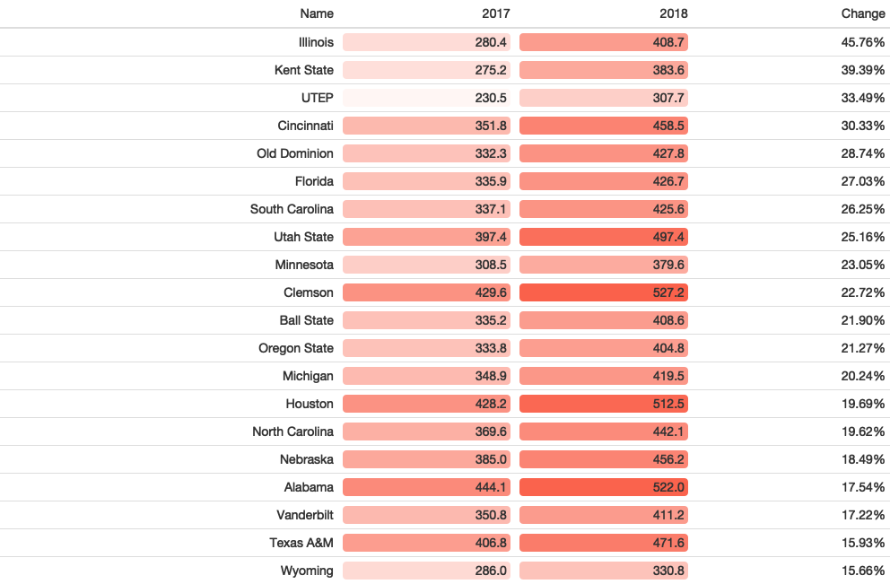

```r
table <- formattable(
  changeTotalOffense,
  align="r",
  list(
     area(col = 2:3) ~ color_tile("#FFF6F4", "#FA614B"),
    `Change` = percent)
  )

export_formattable(table,"table.png")
```

For now, pngs are what you need to export. There is a way to export PDFs, but they lose all the formatting when you do that, which is kind of pointless.

### Assignment

We now have [season logs](https://www.dropbox.com/s/0lpvstsjziz5k6p/logs.csv?dl=0) for every college basketball game played up to the NCAA tournament.

Create a dataframe that shows the 10 best or 10 worst at something. Or rank the Big Ten. Your choice. Then use formattable to show in both a table and visually how the best were different from the worst.

Export it to a PNG using the example above. Then, in Illustrator, add a headline, chatter, source and credit lines. Turn in the PNG file you export from Illustrator.